# Proyecto 2 GDELT

Sergio Haro Perez

25/05/2015

Señala el caso de México. ¿Existen clústers? ¿Qué países son parecidos a México? ¿Puedes desarrollar un modelo predictivo? ¿Qué más bases de datos puedes traer al análisis?

Eventos que se registraron en Mexico por Year. (Todos los eventos).

Necesitamos extraer los codigos Raiz, ya que agruparlos por evento, no podemos descartar los eventos menos ocurrentes, ya que pueden reprensentar sucesos importantes.

Presentamos los eventos generales en el pais desde 1979 a 2015

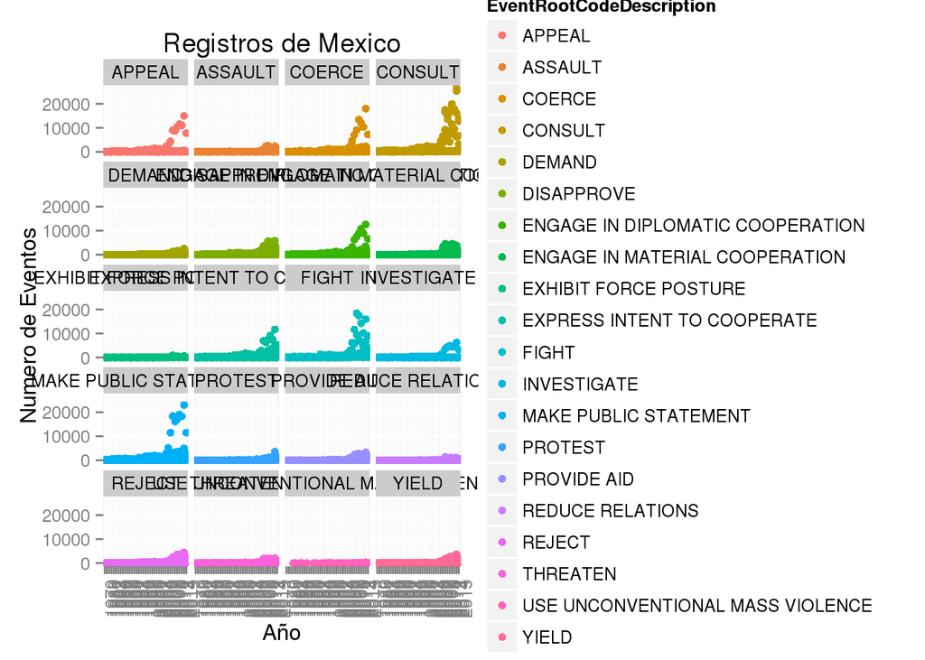

|  | Year | EventRootCode | EventCode | C | EventCodeDescription | EventRootCodeDescription |
| --- | --- | --- | --- | --- | --- | --- |
|  | Min. :1979 | Length:6105 | Length:6105 | Min. : 1.0 | Length:6105 | Length:6105 |
|  | 1st Qu.:1990 | Class :character | Class :character | 1st Qu.: 4.0 | Class :character | Class :character |
|  | Median :1999 | Mode :character | Mode :character | Median : 18.0 | Mode :character | Mode :character |
|  | Mean :1999 | NA | NA | Mean : 330.6 | NA | NA |
|  | 3rd Qu.:2008 | NA | NA | 3rd Qu.: 102.0 | NA | NA |
|  | Max. :2015 | NA | NA | Max. :26487.0 | NA | NA |

El total de eventos registrados es:

```
## [1] 2018438
```

Veamos los eventos mas recurrentes y los menos recurrentes

| Year | EventRootCode | EventCode | C | EventCodeDescription | EventRootCodeDescription |
| --- | --- | --- | --- | --- | --- |
| 2014 | 04 | 042 | 26487 | Make a visit | CONSULT |
| 2014 | 04 | 043 | 25328 | Host a visit | CONSULT |
| 2014 | 01 | 010 | 23013 | Make statement, not specified below | MAKE PUBLIC STATEMENT |
| 2012 | 04 | 042 | 19954 | Make a visit | CONSULT |
| 2012 | 01 | 010 | 19038 | Make statement, not specified below | MAKE PUBLIC STATEMENT |
| 2012 | 04 | 043 | 18998 | Host a visit | CONSULT |
| 2009 | 01 | 010 | 18458 | Make statement, not specified below | MAKE PUBLIC STATEMENT |
| 2010 | 19 | 190 | 18437 | Use conventional military force, not specified below | FIGHT |
| 2013 | 01 | 010 | 18251 | Make statement, not specified below | MAKE PUBLIC STATEMENT |
| 2013 | 04 | 042 | 18012 | Make a visit | CONSULT |

| Year | EventRootCode | EventCode | C | EventCodeDescription | EventRootCodeDescription |
| --- | --- | --- | --- | --- | --- |
| 1979 | 02 | 023 | 1 | Appeal for aid, not specified below | APPEAL |
| 1979 | 15 | 154 | 1 | Mobilize or increase armed forces | EXHIBIT FORCE POSTURE |
| 1979 | 17 | 174 | 1 | Expel or deport individuals | COERCE |
| 1979 | 13 | 1384 | 1 | Threaten conventional attack | THREATEN |
| 1979 | 02 | 0241 | 1 | Appeal for change in leadership | APPEAL |
| 1979 | 05 | 055 | 1 | Apologize | ENGAGE IN DIPLOMATIC COOPERATION |
| 1979 | 18 | 1821 | 1 | Sexually assault | ASSAULT |
| 1979 | 10 | 1014 | 1 | Demand intelligence cooperation | DEMAND |
| 1979 | 16 | 163 | 1 | Impose embargo, boycott, or sanctions | REDUCE RELATIONS |
| 1979 | 10 | 1044 | 1 | Demand change in institutions, regime | DEMAND |

Ahora ,agrupados por Año evento raiz y codigo, presentamos los ocurridos en Mexico

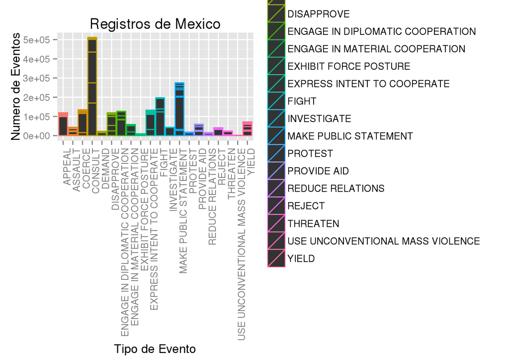

Ahora vamos a centrarnos en informacion de los ultimos 5 años.

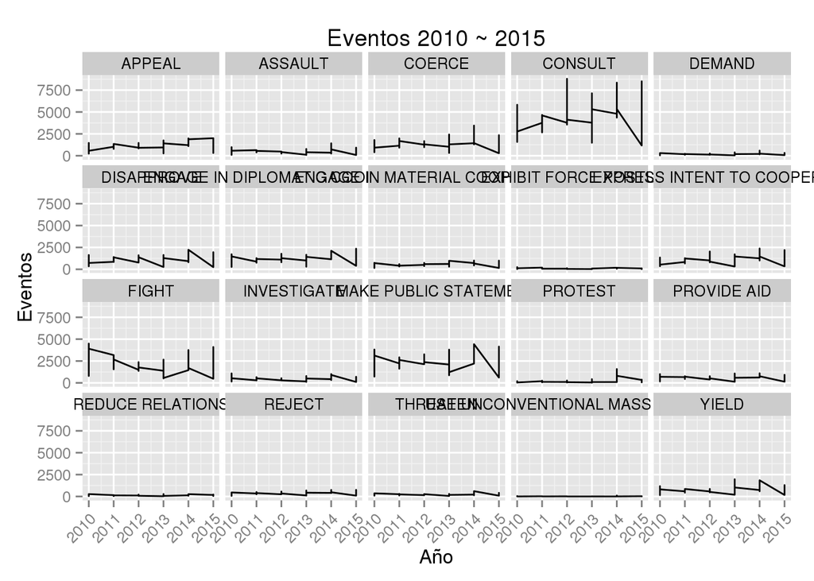

Buscando paises con una relacion con eventos, graficamos el numero de eventos por pais.

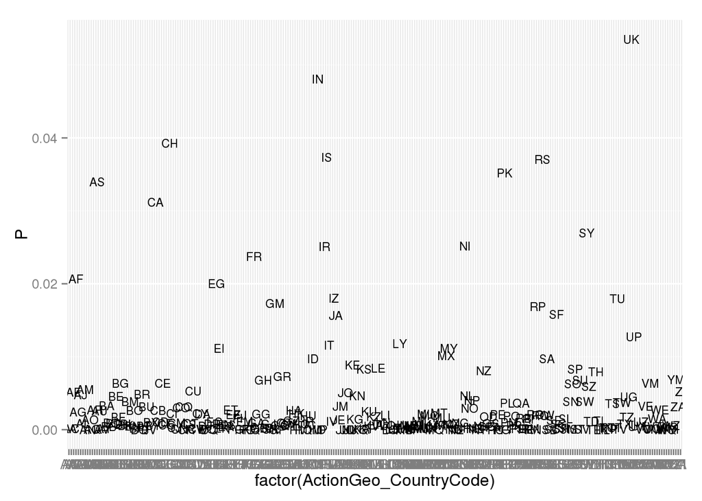

Graficamos el dendograma, pero no se puede apreciar a que cluster pertenece mexico

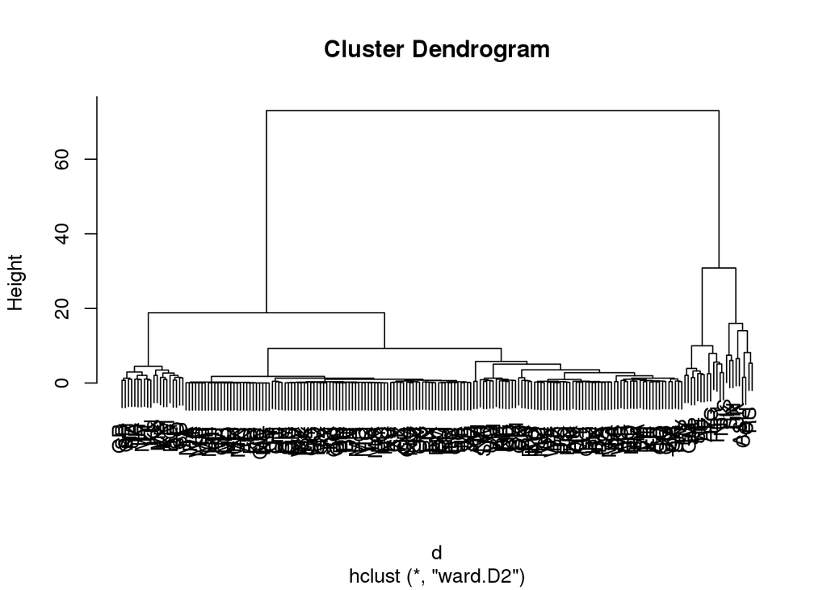

Rebanamos el cluster en 20

```
## groups
##  1  2  3  4  5  6  7  8  9 10 11 12 13 14 15 16 17 18 19 20
## 12  2 52  2 90  2 10  1  1 10  2  5  1  1  1  2  1  1  1  1
```

Buscamos en que grupo quedo mexico:

```
## MX
##  7
```

Vemos que México pertenece al grupo 7

Se agrupa unicamente al que pertenece mexico y visualizamos el nuevo dendograma

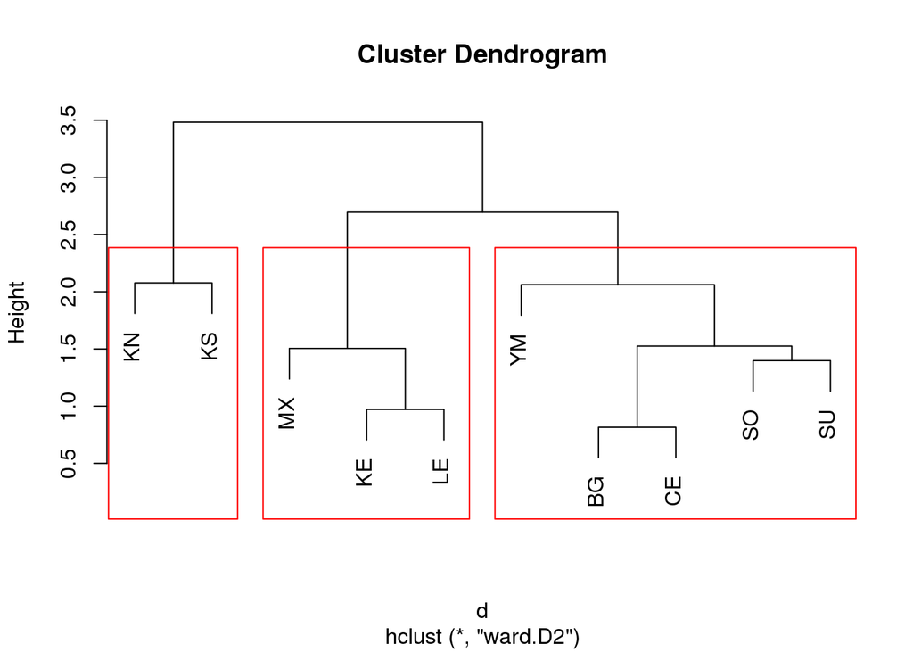

Con esta nueva matriz podemos obtener las correlaciones de mexico

Por Pais

[figure not shown]

y por evento

[figure not shown]